# PCA

2024-03-03

#### Firstly, I have imported my dataset to check the columns, its datatype and other related properties.

```r
library(readr)
apples <- read_csv("D:/Rutgers/R2nd Semester/Multivariate/apple_quality.csv")
attach(apples)
str(apples)
```

```
## spc_tbl_ [4,000 × 9] (S3: spec_tbl_df/tbl_df/tbl/data.frame)
##  $ A_id       : num [1:4000] 0 1 2 3 4 5 6 7 8 9 ...
##  $ Size       : num [1:4000] -3.97 -1.195 -0.292 -0.657 1.364 ...
##  $ Weight     : num [1:4000] -2.51 -2.84 -1.35 -2.27 -1.3 ...
##  $ Sweetness  : num [1:4000] 5.346 3.664 -1.738 1.325 -0.385 ...
##  $ Crunchiness: num [1:4000] -1.012 1.5882 -0.3426 -0.0979 -0.553 ...
##  $ Juiciness  : num [1:4000] 1.845 0.853 2.839 3.638 3.031 ...
##  $ Ripeness   : num [1:4000] 0.33 0.868 -0.038 -3.414 -1.304 ...
##  $ Acidity    : num [1:4000] -0.492 -0.723 2.622 0.791 0.502 ...
##  $ Quality    : chr [1:4000] "good" "good" "bad" "good" ...
##  - attr(*, "spec")=
##   .. cols(
##   ..   A_id = col_double(),
##   ..   Size = col_double(),
##   ..   Weight = col_double(),
##   ..   Sweetness = col_double(),
##   ..   Crunchiness = col_double(),
##   ..   Juiciness = col_double(),
##   ..   Ripeness = col_double(),
##   ..   Acidity = col_double(),
##   ..   Quality = col_character()
##   .. )
##  - attr(*, "problems")=<externalptr>
```

#### The below code I used to get the Correlations between the measurements

```r
cor(apples[, c("Size", "Weight", "Crunchiness", "Sweetness", "Juiciness", "Ripeness", "Acidity")])
```

```
##                    Size      Weight Crunchiness   Sweetness   Juiciness
## Size         1.00000000 -0.17070166  0.16986809 -0.32468025 -0.01889243
## Weight      -0.17070166  1.00000000 -0.09588174 -0.15424632 -0.09226279
## Crunchiness  0.16986809 -0.09588174  1.00000000 -0.03755203 -0.25960709
## Sweetness   -0.32468025 -0.15424632 -0.03755203  1.00000000  0.09588153
## Juiciness   -0.01889243 -0.09226279 -0.25960709  0.09588153  1.00000000
## Ripeness    -0.13477293 -0.24382427 -0.20198163 -0.27380007 -0.09714409
## Acidity      0.19621806  0.01641423  0.06994303  0.08599920  0.24871388
##                Ripeness     Acidity
## Size        -0.13477293  0.19621806
## Weight      -0.24382427  0.01641423
## Crunchiness -0.20198163  0.06994303
## Sweetness   -0.27380007  0.08599920
## Juiciness   -0.09714409  0.24871388
## Ripeness     1.00000000 -0.20266908
## Acidity     -0.20266908  1.00000000
```

### Inference

#### We can see that most of the characteristics of the apple are negatively correlated, which means that if one increases the other one will decrease.

#### The below code is used to get the principle components for the dataset, and also the by how much each principle component is contributing to the overall.

```r
apples_pca <- prcomp(apples[, c("Size", "Weight", "Crunchiness", "Sweetness", "Juiciness", "Ripeness", "Acidity")],scale=TRUE)
apples_pca
```

```
## Standard deviations (1, .., p=7):
## [1] 1.2300383 1.2084352 1.1208633 1.0704722 0.8414584 0.7806741 0.5540223
##
## Rotation (n x k) = (7 x 7):
##                     PC1         PC2        PC3         PC4         PC5
## Size         0.18420141  0.62142234  0.3242914  0.09787343  0.39799695
## Weight       0.04902398 -0.07955161 -0.5216750  0.70624851 -0.12034080
## Crunchiness  0.16439075  0.51057113 -0.3232919 -0.39783140 -0.25242041
## Sweetness    0.34364782 -0.47301989 -0.1920476 -0.52030124  0.04733197
## Juiciness    0.35517821 -0.33344580  0.5142034  0.19433181  0.19230373
## Ripeness    -0.61047903 -0.05385427  0.3923445 -0.06956910 -0.47376791
## Acidity      0.56543094  0.09480897  0.2509004  0.14158361 -0.70691115
##                       PC6        PC7
## Size         3.417321e-01 -0.4358642
## Weight      -2.653110e-02 -0.4529356
## Crunchiness -5.813301e-01 -0.2187339
## Sweetness    3.124459e-01 -0.5006995
## Juiciness   -6.169202e-01 -0.2071741
## Ripeness    -1.441385e-05 -0.4911059
## Acidity      2.575998e-01  0.1490678
```

```r
summary(apples_pca)
```

```
## Importance of components:
##                           PC1    PC2    PC3    PC4    PC5     PC6     PC7
## Standard deviation     1.2300 1.2084 1.1209 1.0705 0.8415 0.78067 0.55402
## Proportion of Variance 0.2161 0.2086 0.1795 0.1637 0.1012 0.08706 0.04385
## Cumulative Proportion  0.2161 0.4248 0.6042 0.7679 0.8691 0.95615 1.00000
```

### Inference

#### From the above analysis I decided to choose PC1 to PC4, to balance between capturing a substantial portion of the variance and retaining interpretability, which cumulatively gives 0.769, which is 90% of the threshold.

#### The next few bits of code explains various steps which are involved in order to arrive at the summary of principle components.

```r
(eigen_apples <- apples_pca$sdev^2)
```

```
## [1] 1.5129941 1.4603157 1.2563345 1.1459107 0.7080523 0.6094520 0.3069407
```

```r
names(eigen_apples) <- paste("PC",1:7,sep="")
eigen_apples
```

```
##       PC1       PC2       PC3       PC4       PC5       PC6       PC7
## 1.5129941 1.4603157 1.2563345 1.1459107 0.7080523 0.6094520 0.3069407
```

### Inference

#### The above has assigned the eigen values based on the principle components.

```r
sumlambdas <- sum(eigen_apples)
sumlambdas
```

```
## [1] 7
```

### Inference

#### The above has calculated the total variance in the data and given it to be 7.

```r
propvar <- eigen_apples/sumlambdas
propvar
```

```
##        PC1        PC2        PC3        PC4        PC5        PC6        PC7
## 0.21614201 0.20861653 0.17947635 0.16370152 0.10115033 0.08706457 0.04384867
```

### Inference

#### The above has calculated the proportion of each variance, by each principle component.

```r
cumvar_apples <- cumsum(propvar)
cumvar_apples
```

```
##       PC1       PC2       PC3       PC4       PC5       PC6       PC7
## 0.2161420 0.4247585 0.6042349 0.7679364 0.8690868 0.9561513 1.0000000
```

### Inference

#### The above calculated the cumulative portion of each component.

```r
matlambdas <- rbind(eigen_apples,propvar,cumvar_apples)
rownames(matlambdas) <- c("Eigenvalues","Prop. variance","Cum. prop. variance")
round(matlambdas,4)
```

```
##                        PC1    PC2    PC3    PC4    PC5    PC6    PC7
## Eigenvalues         1.5130 1.4603 1.2563 1.1459 0.7081 0.6095 0.3069
## Prop. variance      0.2161 0.2086 0.1795 0.1637 0.1012 0.0871 0.0438
## Cum. prop. variance 0.2161 0.4248 0.6042 0.7679 0.8691 0.9562 1.0000
```

### Inference

#### The above shows the summary of the PCAs.

```r
summary(apples_pca)
```

```
## Importance of components:
##                           PC1    PC2    PC3    PC4    PC5     PC6     PC7
## Standard deviation     1.2300 1.2084 1.1209 1.0705 0.8415 0.78067 0.55402
## Proportion of Variance 0.2161 0.2086 0.1795 0.1637 0.1012 0.08706 0.04385
## Cumulative Proportion  0.2161 0.4248 0.6042 0.7679 0.8691 0.95615 1.00000
```

```r
apples_pca$rotation
```

```
##                     PC1         PC2        PC3         PC4         PC5
## Size         0.18420141  0.62142234  0.3242914  0.09787343  0.39799695
## Weight       0.04902398 -0.07955161 -0.5216750  0.70624851 -0.12034080
## Crunchiness  0.16439075  0.51057113 -0.3232919 -0.39783140 -0.25242041
## Sweetness    0.34364782 -0.47301989 -0.1920476 -0.52030124  0.04733197
## Juiciness    0.35517821 -0.33344580  0.5142034  0.19433181  0.19230373
## Ripeness    -0.61047903 -0.05385427  0.3923445 -0.06956910 -0.47376791
## Acidity      0.56543094  0.09480897  0.2509004  0.14158361 -0.70691115
##                       PC6        PC7
## Size         3.417321e-01 -0.4358642
## Weight      -2.653110e-02 -0.4529356
## Crunchiness -5.813301e-01 -0.2187339
## Sweetness    3.124459e-01 -0.5006995
## Juiciness   -6.169202e-01 -0.2071741
## Ripeness    -1.441385e-05 -0.4911059
## Acidity      2.575998e-01  0.1490678
```

```r
print(apples_pca)
```

```
## Standard deviations (1, .., p=7):
## [1] 1.2300383 1.2084352 1.1208633 1.0704722 0.8414584 0.7806741 0.5540223
##
## Rotation (n x k) = (7 x 7):
##                     PC1         PC2        PC3         PC4         PC5
## Size         0.18420141  0.62142234  0.3242914  0.09787343  0.39799695
## Weight       0.04902398 -0.07955161 -0.5216750  0.70624851 -0.12034080
## Crunchiness  0.16439075  0.51057113 -0.3232919 -0.39783140 -0.25242041
## Sweetness    0.34364782 -0.47301989 -0.1920476 -0.52030124  0.04733197
## Juiciness    0.35517821 -0.33344580  0.5142034  0.19433181  0.19230373
## Ripeness    -0.61047903 -0.05385427  0.3923445 -0.06956910 -0.47376791
## Acidity      0.56543094  0.09480897  0.2509004  0.14158361 -0.70691115
##                       PC6        PC7
## Size         3.417321e-01 -0.4358642
## Weight      -2.653110e-02 -0.4529356
## Crunchiness -5.813301e-01 -0.2187339
## Sweetness    3.124459e-01 -0.5006995
## Juiciness   -6.169202e-01 -0.2071741
## Ripeness    -1.441385e-05 -0.4911059
## Acidity      2.575998e-01  0.1490678
```

```r
apples_pca$x
```

```
##                   PC1           PC2           PC3           PC4           PC5
##    [1,]  0.5644273292 -3.4355872439  0.0503266217 -1.7356073265  0.2655626717
##    [2,]  0.4072517404 -1.0236774188  0.0113327258 -2.1611937784  0.1967926844
##    [3,]  0.9138510929 -0.3609788235  1.3946829770  0.9922648684 -0.2063040159
##    [4,]  2.1770925940 -1.2128446647  0.5624106847 -0.2384825861  1.3641861864
##    [5,]  1.1681693211 -0.3280244939  1.1044100310  0.7217892666  1.2514527114
##    [6,] -2.8117838425 -0.5548655281 -1.0871486155 -0.2070323735 -0.0978892754
##    [7,]  2.0491382398 -1.1118512128  0.4125996000  2.1501255909  0.7619541764
##    [8,] -0.6087393877 -1.6471818933 -0.4112828871 -0.0312771409  0.3722676338
##    [9,] -2.5699695962 -2.7339013579  1.3250368434 -1.4343215214  0.8713800180
##   [10,] -0.5130255144  0.7235886692  0.6856385832  1.3970749737 -1.1078165123
##   [11,] -1.9544311765 -1.5809610846  0.9661367280  0.3349819061  0.2572767324
##   [12,] -0.3010491098  1.6818920236  0.0855515542  0.4548212635 -0.2905616963
##   [13,] -0.9326312884  1.5456008253 -1.3106748546 -0.8923238546  0.4916808728
##   [14,]  0.9864552929 -0.5801023377 -0.0493270862 -1.0518939328 -0.6906974822
```

[output cut: 7987 more lines]

### Inference

#### The proportion of variance explained by each principal component is given. PC1 explains the highest proportion, and the cumulative proportion shows that the first few components capture a significant amount of the overall variability.

#### The rotation matrix (apples_pca$rotation) is indicating the relationship between the original variables and the principal components.

```r
apptyp_pca <- cbind(data.frame(Quality),apples_pca$x)
apptyp_pca
```

```
##      Quality           PC1           PC2           PC3           PC4
## 1       good  0.5644273292 -3.4355872439  0.0503266217 -1.7356073265
## 2       good  0.4072517404 -1.0236774188  0.0113327258 -2.1611937784
## 3        bad  0.9138510929 -0.3609788235  1.3946829770  0.9922648684
## 4       good  2.1770925940 -1.2128446647  0.5624106847 -0.2384825861
## 5       good  1.1681693211 -0.3280244939  1.1044100310  0.7217892666
## 6        bad -2.8117838425 -0.5548655281 -1.0871486155 -0.2070323735
## 7       good  2.0491382398 -1.1118512128  0.4125996000  2.1501255909
## 8       good -0.6087393877 -1.6471818933 -0.4112828871 -0.0312771409
## 9        bad -2.5699695962 -2.7339013579  1.3250368434 -1.4343215214
## 10       bad -0.5130255144  0.7235886692  0.6856385832  1.3970749737
## 11       bad -1.9544311765 -1.5809610846  0.9661367280  0.3349819061
## 12      good -0.3010491098  1.6818920236  0.0855515542  0.4548212635
## 13       bad -0.9326312884  1.5456008253 -1.3106748546 -0.8923238546
## 14      good  0.9864552929 -0.5801023377 -0.0493270862 -1.0518939328
```

[output cut: 7987 more lines]

#### In the below code we are trying to see how far the good or bad quality is from the mean 0 for each PC.

```r
tabmeansPC <- aggregate(apptyp_pca[,2:8],by=list(Quality=apples$Quality),mean)
tabmeansPC
```

```
##   Quality        PC1         PC2         PC3         PC4        PC5
## 1     bad -0.3793791  0.04688094 -0.06247625  0.03297974 -0.2932036
## 2    good  0.3778646 -0.04669379  0.06222685 -0.03284809  0.2920331
##            PC6        PC7
## 1 -0.006462033  0.1555088
## 2  0.006436236 -0.1548880
```

### Inference

#### We can observe that for all the PCs the good and bad quality are negatively correlated.

```r
tabmeansPC <- tabmeansPC[rev(order(tabmeansPC$Quality)),]
tabmeansPC
```

```
##   Quality        PC1         PC2         PC3         PC4        PC5
## 2    good  0.3778646 -0.04669379  0.06222685 -0.03284809  0.2920331
## 1     bad -0.3793791  0.04688094 -0.06247625  0.03297974 -0.2932036
##            PC6        PC7
## 2  0.006436236 -0.1548880
## 1 -0.006462033  0.1555088
```

### Inference

#### The above result shows the reverse of the previous process, because we performed the reverse function.

```r
tabfmeans <- t(tabmeansPC[,-1])
tabfmeans
```

```
##                2            1
## PC1  0.377864621 -0.379379108
## PC2 -0.046693789  0.046880939
## PC3  0.062226845 -0.062476252
## PC4 -0.032848087  0.032979743
## PC5  0.292033123 -0.293203596
## PC6  0.006436236 -0.006462033
## PC7 -0.154888003  0.155508797
```

```r
colnames(tabfmeans) <- t(as.vector(tabmeansPC[1]$Quality))
tabfmeans
```

```
##             good          bad
## PC1  0.377864621 -0.379379108
## PC2 -0.046693789  0.046880939
## PC3  0.062226845 -0.062476252
## PC4 -0.032848087  0.032979743
## PC5  0.292033123 -0.293203596
## PC6  0.006436236 -0.006462033
## PC7 -0.154888003  0.155508797
```

### Inference for the above two bits of the code

#### For PC1, PC3, PC5, PC6, variables with higher positive loadings contribute more to the “good” category, while variables with higher negative loadings contribute more to the “bad” category. For PC2, PC4, PC7, variables with higher positive loadings contribute more to the “bad” category, while variables with higher negative loadings contribute more to the “good” category.

```r
tabsdsPC <- aggregate(apptyp_pca[,2:8],by=list(Quality=apples$Quality),sd)
tabfsds <- t(tabsdsPC[,-1])
colnames(tabfsds) <- t(as.vector(tabsdsPC[1]$Quality))
tabfsds
```

```
##           bad      good
## PC1 1.2665105 1.0661989
## PC2 1.0946549 1.3106002
## PC3 1.0736335 1.1629401
## PC4 0.9705310 1.1608121
## PC5 0.8928768 0.6697698
## PC6 0.6426052 0.8974402
## PC7 0.4517497 0.6012032
```

### Inference

#### Now we are performing visualization.

### Scree Diagram

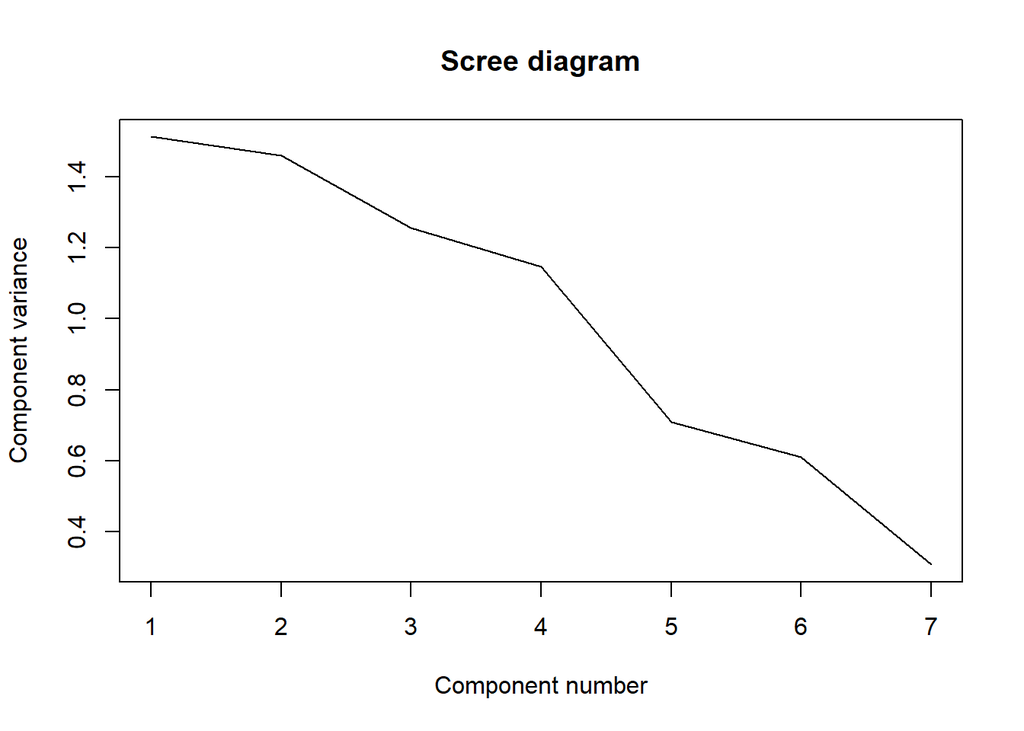

```r
plot(eigen_apples, xlab = "Component number", ylab = "Component variance", type = "l", main = "Scree diagram")
```

### Inference

#### From the above graph, we can stop at any of the sharp edges, according to my analysis above, I have decided to retain only till PC4, to balance between capturing a substantial portion of the variance and retaining interpretability, which cumulatively gives 0.769, which is 90% of the threshold.

### Log Diagram

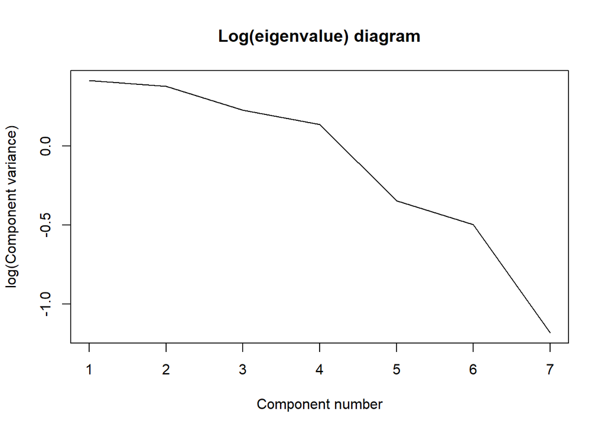

```r
plot(log(eigen_apples), xlab = "Component number",ylab = "log(Component variance)", type="l",main = "Log(eigenvalue) diagram")
```

### Inference

#### From the above graph, we can stop at any of the sharp edges, according to my analysis above, I have decided to retain only till PC4, to balance between capturing a substantial portion of the variance and retaining interpretability, which cumulatively gives 0.769, which is 90% of the threshold.

### Correaltion Graph

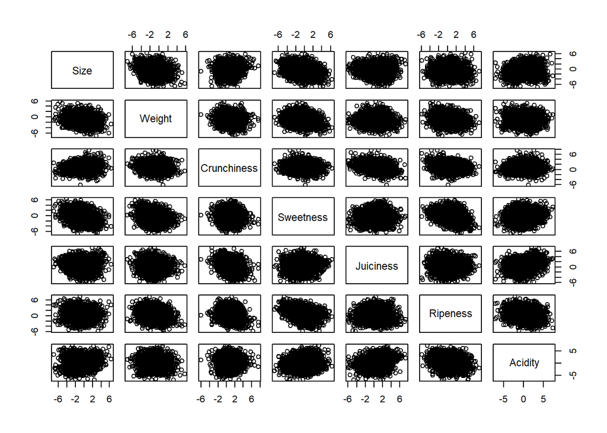

```r
plot(apples[, c("Size", "Weight", "Crunchiness", "Sweetness", "Juiciness", "Ripeness", "Acidity")])
```

### Inference

#### The above analysis shows that the characteristics are positively and negatively related.

#### The below is used to plot the variance against the principle components.

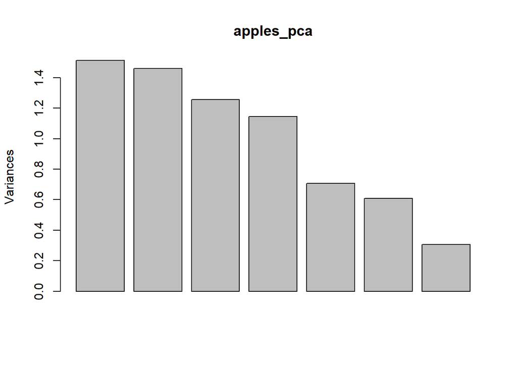

```r
plot(apples_pca)
```

### Box Plots

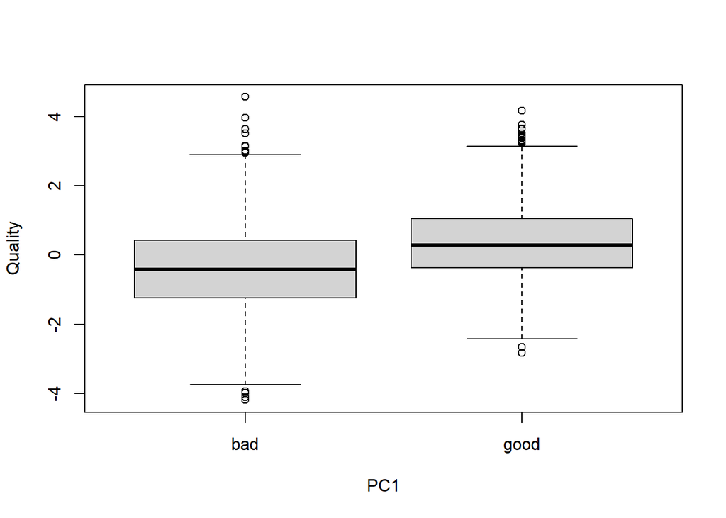

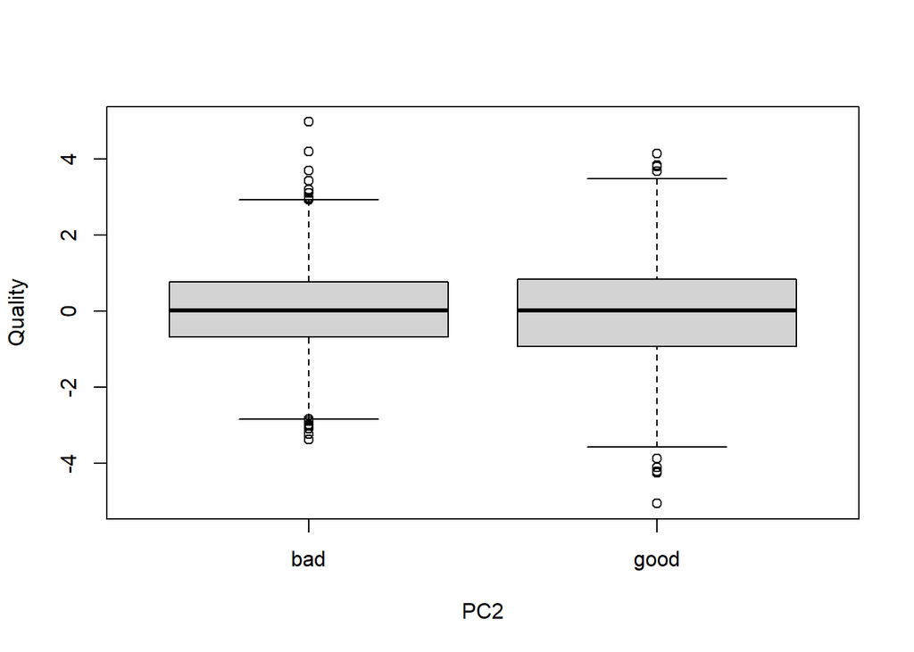

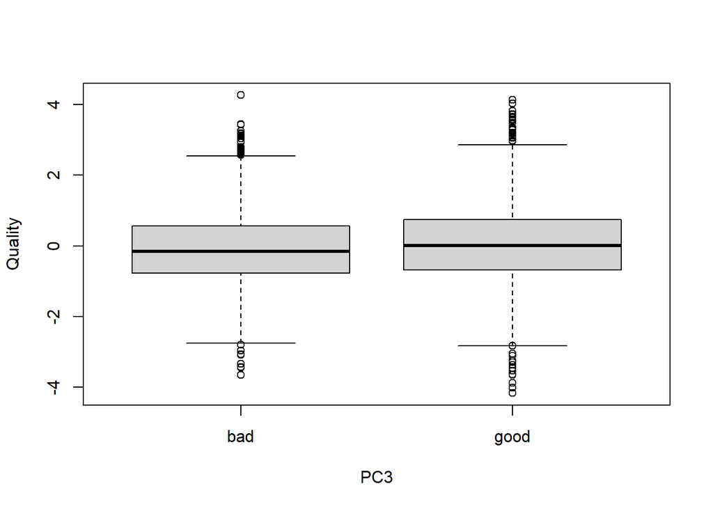

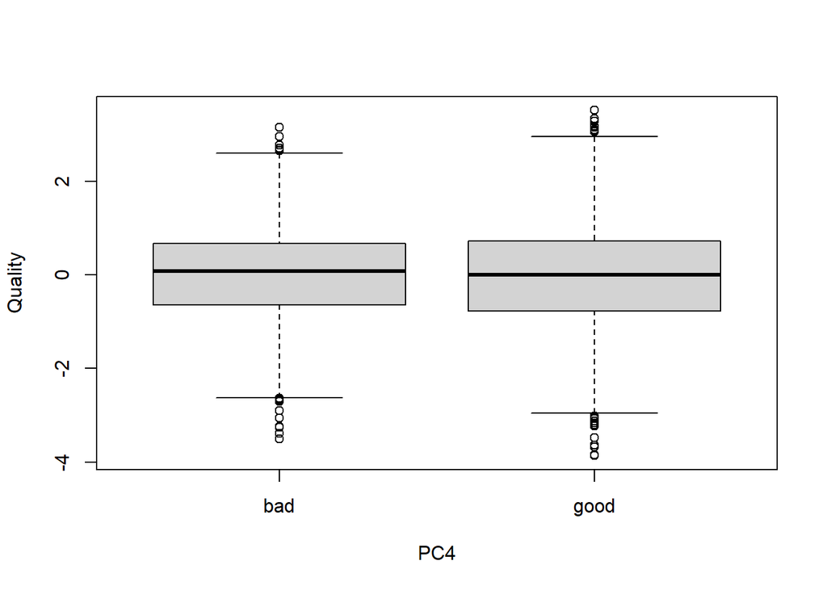

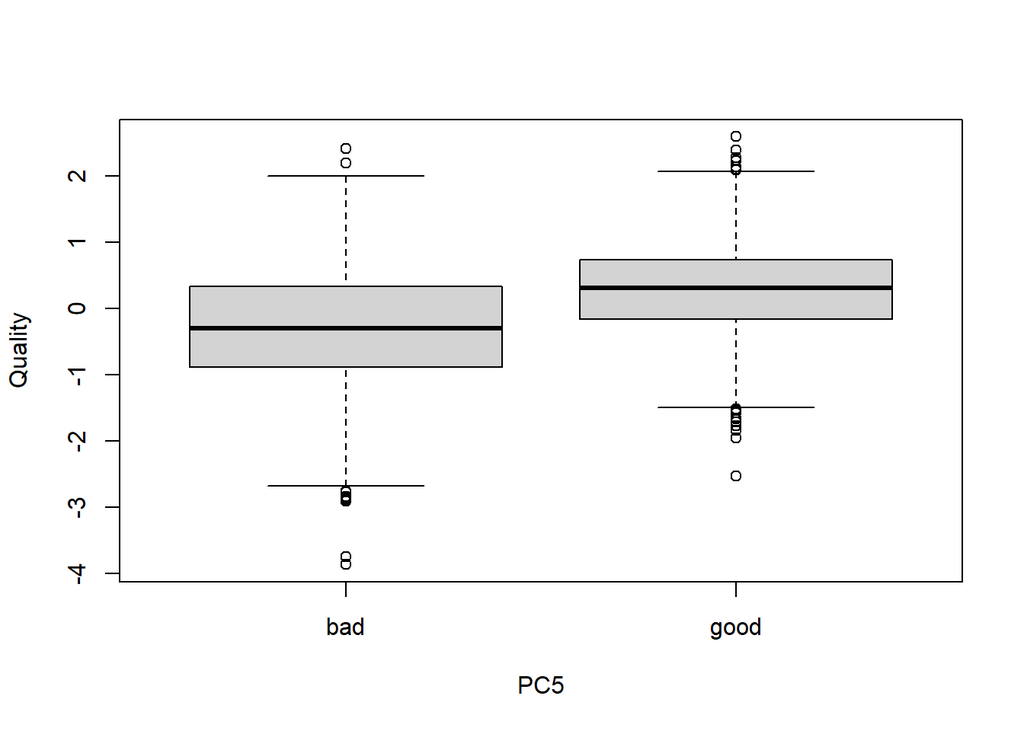

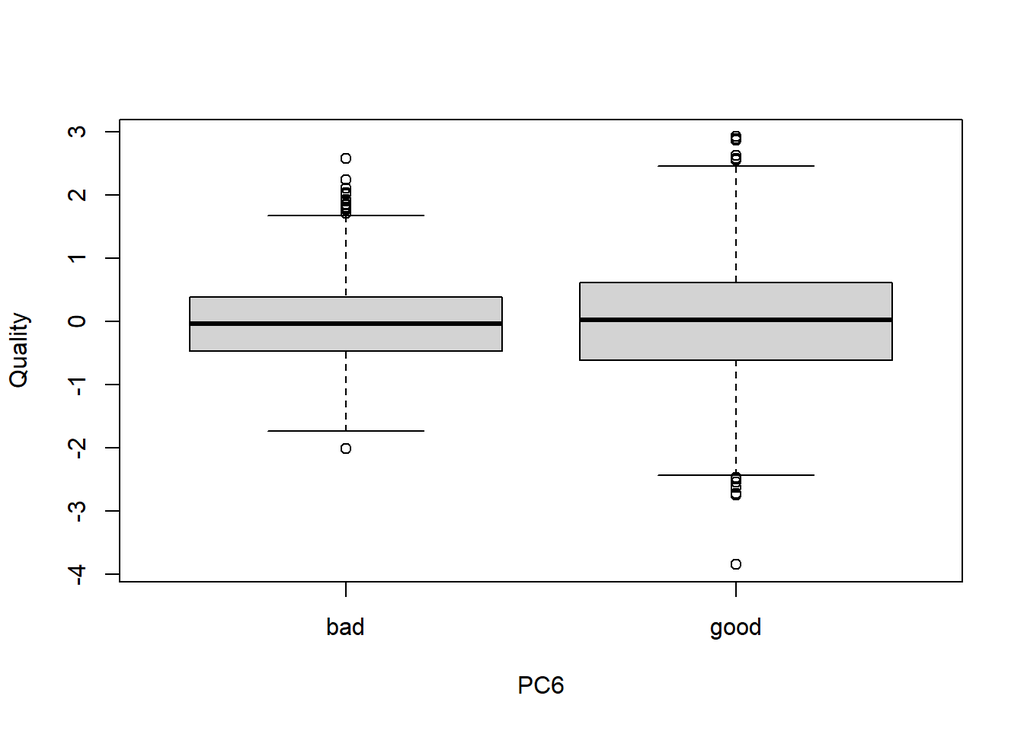

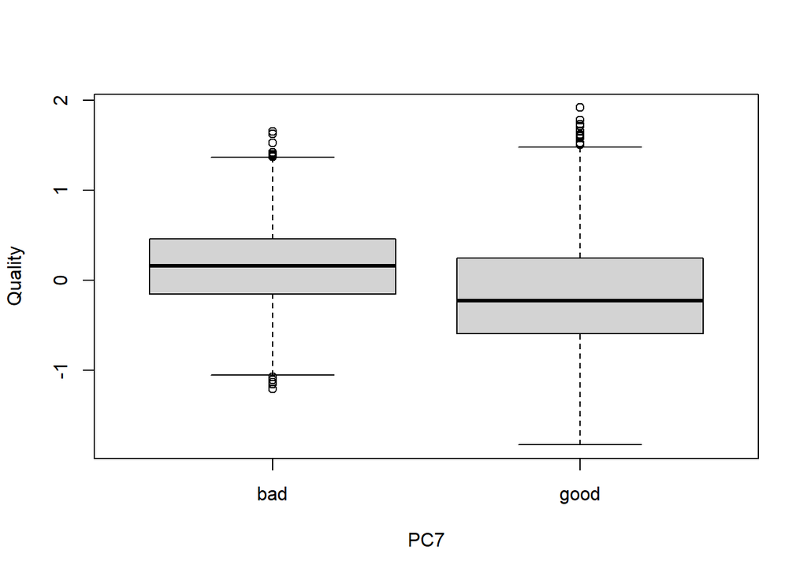

```r
apples$Quality <- as.factor(apples$Quality)
out <- sapply(1:7, function(i){plot(apples$Quality,apples_pca$x[,i],xlab=paste("PC",i,sep=""),ylab="Quality")})
```

### Inference

#### Center of the Box (Median), indicates the median score for each principal component. The Box Spread (Interquartile Range), represents the spread of the scores around the median, offering insights into the variability. The Whiskers, illustrate the range of the scores within a certain threshold, helping identify outliers.

### Variable Factor Map

```r
chooseCRANmirror(ind = 1)
install.packages("factoextra")
library(factoextra)
```

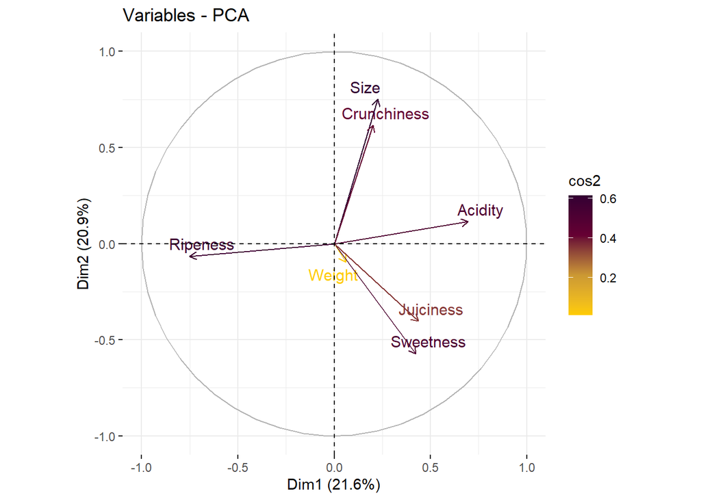

```r
fviz_pca_var(apples_pca,col.var = "cos2",
             gradient.cols = c("#FFCC00", "#CC9933", "#660033", "#330033"),
             repel = TRUE)
```